# Editorial

“Editorial” published in The R Journal.

Catherine Hurley https://journal.r-project.org (Maynooth University)  
2022-09-01

On behalf of the editorial board, I am pleased to present Volume 14 Issue 3 of the R Journal.

Our incoming editor-in-chief for 2023 Simon Urbanek has been successful in seeking funding from the R Consortium. The project will provide a web-based front-end for managing the R Journal submission and review process.

Behind the scenes, several people assist with the journal operations. Mitchell O’Hara-Wild continues to work on infrastructure, and thanks to this work, producing a new issue is far more straightforward. H. Sherry Zhang continues to develop the rjtools package under the direction of Professor Dianne Cook. This package, recently available from CRAN assists in producing RMarkdown articles in the R Journal format. In addition, articles in this issue have been carefully copy edited by Hannah Comiskey.

## In this issue

News from the CRAN and Bioconductor are included in this issue.

This issue features 18 contributed research articles the majority of which relate to R packages on a diverse range of topics. All packages are available on CRAN. The most common article keywords in this issue are

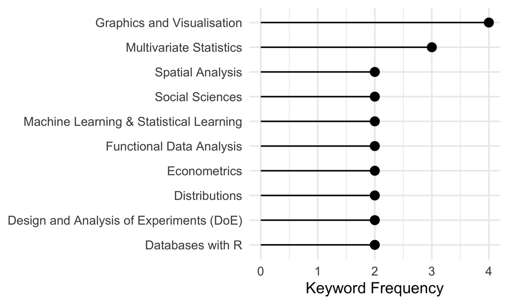

For the first time, we give times from submission to article acceptabce for an issue. Median times are just under a year, which is consistent other issues over the last few years.

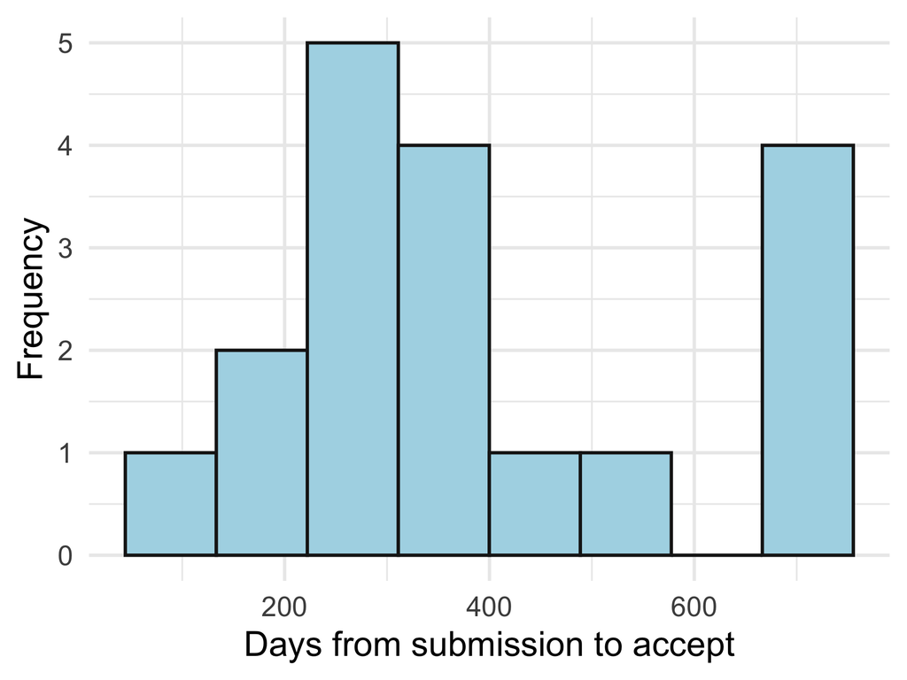

## CRAN packages used

rjtools